# Dada2 Pipeline

Meghan Craughwell

2023-10-19

Load the necessary libraries

```r
library(dada2)
library(phyloseq)
library(Biostrings)
```

```r
library(ggplot2)
library(tidyverse)
```

Make sure you have the reference database downloaded here https://benjjneb.github.io/dada2/training.html (Silva because this is 16S data)

Set working directory and create object

```r
setwd("C:/Users/mcrau/Documents/Rwork/Assignment3")
#create object for the files that you're working with
path<-"C:/Users/mcrau/Documents/Rwork/Assignment3/Seq"
list.files(path)
```

```
## [1] "filtered"                            "Nig-ALH1_S131_L001_R1_001.fastq.gz"
## [3] "Nig-ALH1_S131_L001_R2_001.fastq.gz"  "Nig-ALNeg_S155_L001_R1_001.fastq.gz"
## [5] "Nig-ALNeg_S155_L001_R2_001.fastq.gz" "Nig-ALT2_S119_L001_R1_001.fastq.gz"
## [7] "Nig-ALT2_S119_L001_R2_001.fastq.gz"
```

## Dada2 pipeline to identify taxa

Match the forward and reverse data and change names

```r
## Forward and reverse fastq filenames have format: SAMPLENAME_R1_001.fastq and SAMPLENAME_R2_001.fastq
#if file naming system is different, change the pattern parameter to match the new pattern
fnFs <- sort(list.files(path, pattern="_R1_001.fastq.gz", full.names = TRUE))
fnRs <- sort(list.files(path, pattern="_R2_001.fastq.gz", full.names = TRUE))
# Extract sample names, assuming filenames have format: SAMPLENAME_XXX.fastq (strips the end of the file names off)
sample.names <- sapply(strsplit(basename(fnFs), "_"), `[`, 1)
```

Inspect the plots

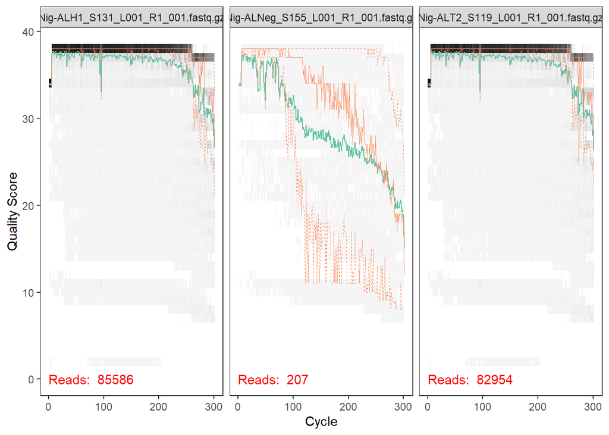

```r
#visualize quality of the forward reads for the first 2 (subsetting the data but you can change this if you want to look at others)
plotQualityProfile(fnFs[1:3])
```

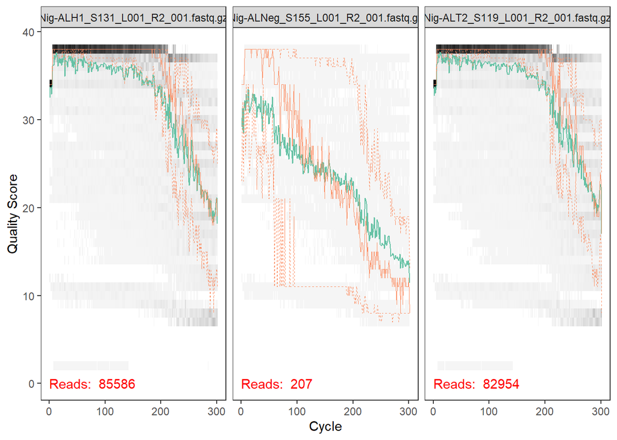

```r
#visualize quality of the reverse reads
plotQualityProfile(fnRs[1:3])
```

Create folders for filtered/trimmed data (not throwing out the original)

```r
# Place filtered files in filtered/ subdirectory
filtFs <- file.path(path, "filtered", paste0(sample.names, "_F_filt.fastq.gz"))
filtRs <- file.path(path, "filtered", paste0(sample.names, "_R_filt.fastq.gz"))
names(filtFs) <- sample.names
names(filtRs) <- sample.names
```

Trim and specify truncLen c(x,x) according to cutoff values decided from plot for forward and reverse **make sure to adjust values**

```r
out <- filterAndTrim(fnFs, filtFs, fnRs, filtRs, truncLen=c(280,220),
              maxN=0, maxEE=c(2,2), truncQ=2, rm.phix=TRUE,
              compress=TRUE, multithread=FALSE)
```

```r
#shows how many sequences were trimmed out
head(out)
```

```
##                                     reads.in reads.out
## Nig-ALH1_S131_L001_R1_001.fastq.gz     85586     74186
## Nig-ALNeg_S155_L001_R1_001.fastq.gz      207        61
## Nig-ALT2_S119_L001_R1_001.fastq.gz     82954     73876
```

```r
#error rate for forward reads
errF <- learnErrors(filtFs, multithread=FALSE)
```

```
## 41474440 total bases in 148123 reads from 3 samples will be used for learning the error rates.
```

```r
#error rate for reverse reads
errR <- learnErrors(filtRs, multithread=FALSE)
```

```
## 32587060 total bases in 148123 reads from 3 samples will be used for learning the error rates.
```

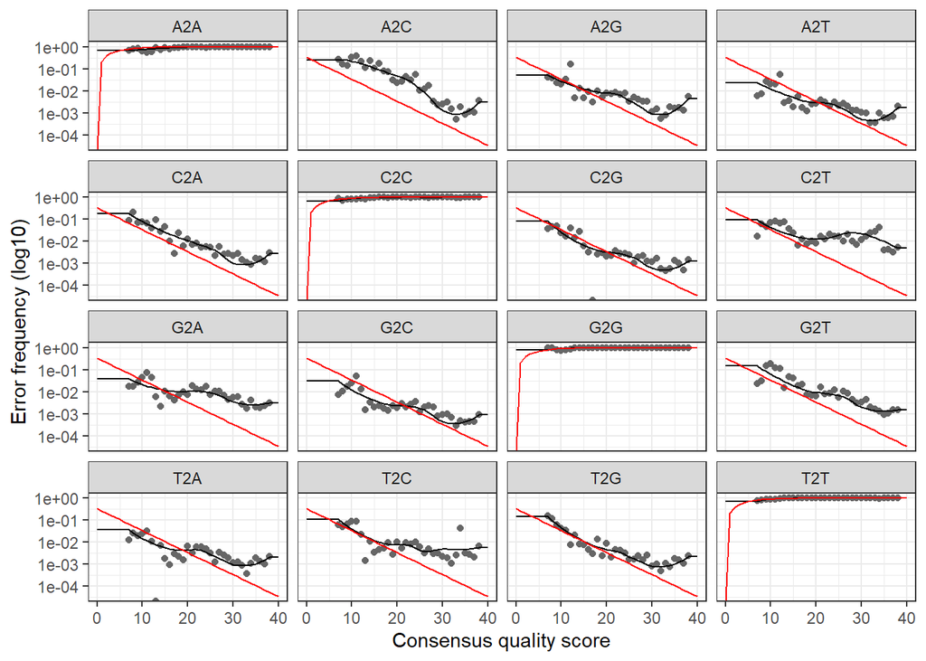

```r
#plot the error rates
plotErrors(errF, nominalQ=TRUE)
```

Determine how many unique reads for forward and reverse

```r
dadaFs <- dada(filtFs, err=errF, multithread=FALSE)
```

```
## Sample 1 - 74186 reads in 25686 unique sequences.
## Sample 2 - 61 reads in 57 unique sequences.
## Sample 3 - 73876 reads in 32010 unique sequences.
```

```r
dadaRs <- dada(filtRs, err=errR, multithread=FALSE)
```

```
## Sample 1 - 74186 reads in 31321 unique sequences.
## Sample 2 - 61 reads in 59 unique sequences.
## Sample 3 - 73876 reads in 35729 unique sequences.
```

Merge the paired reads

```r
mergers <- mergePairs(dadaFs, filtFs, dadaRs, filtRs, verbose=TRUE)
```

```
## 57022 paired-reads (in 4370 unique pairings) successfully merged out of 67974 (in 7267 pairings) input.
```

```
## 2 paired-reads (in 1 unique pairings) successfully merged out of 2 (in 1 pairings) input.
```

```
## 51188 paired-reads (in 3370 unique pairings) successfully merged out of 65813 (in 6813 pairings) input.
```

```r
# Inspect the merger data.frame from the first sample
head(mergers[[1]])
```

```
##                                                                                                                                                                                                                                                                                                          …
## 1 GTGCCAGCAGCCGCGGTAATACGGGGGGTGCGAGCGTTGTCCGGAATCACTGGGCGTAAA…
## 2   GTGCCAGCCGCCGCGGTAATACGTAGGGTGCGAGCGTTAATCGGAATTACTGGGCGTAAA…
## 3 GTGTCAGCAGCCGCGGTAATACGGGGGGTGCGAGCGTTGTCCGGAATCACTGGGCGTAAA…
## 4 GTGCCAGCCGCCGCGGTAATACGGGGGGTGCGAGCGTTGTCCGGAATCACTGGGCGTAAA…
## 5 GTGCCAGCAGCCGCGGTAATACGGGGGGTGCGAGCGTTGTCCGGAATCACTGGGCGTAAA…
## 6 GTGTCAGCAGCCGCGGTAATACGGGGGGTGCGAGCGTTGTCCGGAATCACTGGGCGTAAA…
##   abundance forward reverse nmatch nmismatch nindel prefer accept
## 1       111       1       1     87         0      0      1   TRUE
## 2       105     193      87     89         0      0      1   TRUE
## 3       102       5       1     87         0      0      1   TRUE
## 4        98       3       1     87         0      0      1   TRUE
## 5        97       1      28     87         0      0      1   TRUE
## 6        96       5      28     87         0      0      1   TRUE
```

Make a sequence table

```r
seqtab <- makeSequenceTable(mergers)
#look at the dimensions of table
dim(seqtab)
```

```
## [1]    3 7369
```

```r
# Inspect distribution of sequence lengths (sometimes you would remove outliers for length)
table(nchar(getSequences(seqtab)))
```

```
##
##  282  405  407  408  409  410  411  412  413  414  415  416  418  431  432  433
##    1    1   85    1  338   24 1329  790 3903  388  495    3    6    1    1    1
##  450  469
##    1    1
```

Remove chimeras

```r
seqtab.nochim <- removeBimeraDenovo(seqtab, method="consensus", multithread=TRUE, verbose=TRUE)
```

```
## Identified 4715 bimeras out of 7369 input sequences.
```

```r
dim(seqtab.nochim)
```

```
## [1]    3 2654
```

```r
#shows how many of the reads remain
sum(seqtab.nochim)/sum(seqtab)
```

```
## [1] 0.6075112
```

Show how many reads made it through each step of the pipeline

```r
#not necessary but nice to see
#and helpful if you lose a lot of sequences as you can see where things went wrong
getN <- function(x) sum(getUniques(x))
track <- cbind(out, sapply(dadaFs, getN), sapply(dadaRs, getN), sapply(mergers, getN), rowSums(seqtab.nochim))
# If processing a single sample, remove the sapply calls: e.g. replace sapply(dadaFs, getN) with getN(dadaFs)
colnames(track) <- c("input", "filtered", "denoisedF", "denoisedR", "merged", "nonchim")
rownames(track) <- sample.names
head(track)
```

```
##           input filtered denoisedF denoisedR merged nonchim
## Nig-ALH1  85586    74186     70761     70643  57022   32949
## Nig-ALNeg   207       61         8         4      2       2
## Nig-ALT2  82954    73876     68866     69541  51188   32789
```

Assign taxonomy

```r
#make sure to set directory and make sure file path is correct
taxa <- assignTaxonomy(seqtab.nochim, "C:/Users/mcrau/Documents/Rwork/Dada2/silva_nr99_v138.1_train_set.fa.gz", multithread=FALSE)
#show the taxonomic units tha that have been assigned
taxa.print <- taxa # Removing sequence rownames for display only
rownames(taxa.print) <- NULL
head(taxa.print)
```

```
##      Kingdom    Phylum              Class              Order
## [1,] "Bacteria" "Bacteroidota"      "Bacteroidia"      "Chitinophagales"
## [2,] "Bacteria" "Verrucomicrobiota" "Verrucomicrobiae" "Chthoniobacterales"
## [3,] "Bacteria" "Verrucomicrobiota" "Verrucomicrobiae" "Chthoniobacterales"
## [4,] "Bacteria" "Latescibacterota"  NA                 NA
## [5,] "Bacteria" "Verrucomicrobiota" "Verrucomicrobiae" "Chthoniobacterales"
## [6,] "Bacteria" "Verrucomicrobiota" "Verrucomicrobiae" "Chthoniobacterales"
##      Family                Genus
## [1,] "Chitinophagaceae"    "Ferruginibacter"
## [2,] "Chthoniobacteraceae" "Candidatus Udaeobacter"
## [3,] "Chthoniobacteraceae" "Candidatus Udaeobacter"
## [4,] NA                    NA
## [5,] "Chthoniobacteraceae" "Candidatus Udaeobacter"
## [6,] "Chthoniobacteraceae" "Candidatus Udaeobacter"
```

Save data up to this point as csv files *(name appropriately)*

Save the file with assigned taxonomy write.csv(taxa, file=“C:/Users/mcrau/Documents/Rwork/Assignment3/Assignment3_taxa_take2.csv”) Save the sequence file after trimming and chimeras removed write.csv(seqtab.nochim, file=“C:/Users/mcrau/Documents/Rwork/Assignment3/Assignment3_seqtab_nochim_take2.csv”)

## Phyloseq before graphing

Phyloseq only works with a matrix instead of a dataframe so convert this data (matrix contains only one class of data whereas a dataframe can contain multiple classes)

```r
seqtab.nochim<-as.matrix(seqtab.nochim)
taxa<-as.matrix(taxa)
```

It is useful to have ASV abundance and taxa in the same csv file if you need to refer to it again

```r
#transpose the seqtab.nochim data (but as a dataframe because when combining with taxa, there will be multiple data classes)
flipped_seqtab.nochim<-as.data.frame(t(seqtab.nochim))
```

Merge the files (use the column bind function)

```r
ASV.taxa<-cbind(flipped_seqtab.nochim, taxa)
```

Save the file to computer *(name appropriately)* write.csv(ASV.taxa, file=“C:/Users/mcrau/Documents/Rwork/Assignment3/Assignment3_ASV_taxa_take2.csv”)

## Graphing with GGplot2

Make a dataframe (saying take row names aka sample names and make a dataframe)

```r
samples.out <- rownames(seqtab.nochim)
samdf<-data.frame(samples.out)
rownames(samdf)<-samples.out
```

Create phyloseq object

```r
#specifying for phyloseq where to find abundance data, where to find taxa, where to find sample names
ps <- phyloseq(otu_table(seqtab.nochim, taxa_are_rows=FALSE), sample_data(samdf), tax_table(taxa))
```

Next step to use ASV instead of the super long sequence (not a necessary step to make graphs but nice to do) so it will just be ASV1, ASV2, etc. Strip the sequence away but this data will be stored

```r
dna <- Biostrings::DNAStringSet(taxa_names(ps))
names(dna) <- taxa_names(ps)
ps <- merge_phyloseq(ps, dna)
taxa_names(ps) <- paste0("ASV", seq(ntaxa(ps)))
ps
```

```
## phyloseq-class experiment-level object
## otu_table()   OTU Table:         [ 2654 taxa and 3 samples ]
## sample_data() Sample Data:       [ 3 samples by 1 sample variables ]
## tax_table()   Taxonomy Table:    [ 2654 taxa by 6 taxonomic ranks ]
## refseq()      DNAStringSet:      [ 2654 reference sequences ]
```

To use ggplot, need to get data out of phyloseq and back to dataframe

```r
ps.table<-psmelt(ps)
#need to factor the data in order to be able to graph it (want to graph phylum so factor phylum and put it back into the table where it was)
ps.table$Phylum<-factor(ps.table$Phylum)
```

Currently have abundance within the samples, but they have different totals so it is difficult to compare between samples. Use relative abundance instead

```r
#use phyloseq (relative abundance is percentage of the total community)
relative.abund<-transform_sample_counts(ps, function(OTU) OTU/sum(OTU))
#back to a dataframe out of phyloseq
ps.proptable<-psmelt(relative.abund)
#factor phylum
ps.proptable$Phylum<-factor(ps.proptable$Phylum)
```

Create a bar plot of realtive abundance by phylum

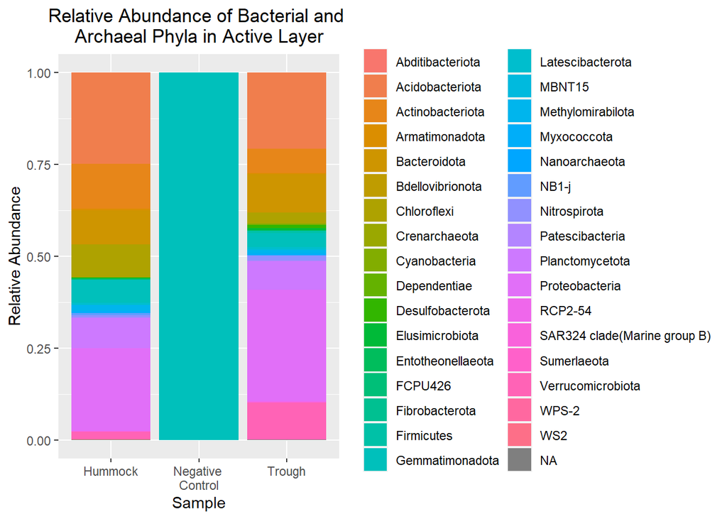

```r
ggplot(data=ps.proptable, mapping=aes(x=Sample, y=Abundance)) +geom_col(aes(fill=Phylum)) + labs(y="Relative Abundance",title="Relative Abundance of Bacterial and \nArchaeal Phyla in Active Layer",x= "Sample") + theme(plot.title = element_text(hjust = 0.5), legend.title=element_blank()) +
scale_x_discrete(labels=c("Hummock","Negative \nControl","Trough"))
```

Create a bar graph of relative abundance by Order(do not have to factor Order before doing)

[figure not shown]

```r
ggplot(data=ps.proptable, mapping=aes(x=Sample, y=Abundance)) +geom_col(aes(fill=Order), position="fill") +theme(plot.title = element_text(hjust = 0.5), legend.title=element_blank(),legend.text=element_text(size=7),legend.key.height= unit(0.5, 'cm'),legend.key.width= unit(0.5, 'cm'))+ guides(fill = guide_legend(ncol = 5))        + labs(y="Relative Abundance",title="Relative Abundance of Bacterial and \nArchaeal Order in Active Layer",x= "Sample")   + scale_x_discrete(labels=c("Hummock","Negative \nControl","Trough"))
```

Find relative abundance (%) at phylum level and use psmelt to obtain data frame again

```r
phy <- ps %>% tax_glom(taxrank = "Phylum") %>% transform_sample_counts(function(x) {(x/sum(x))*100}) %>% psmelt()
```

Bubble plot using phylum relative abundance (%) with specified breaks in percentages

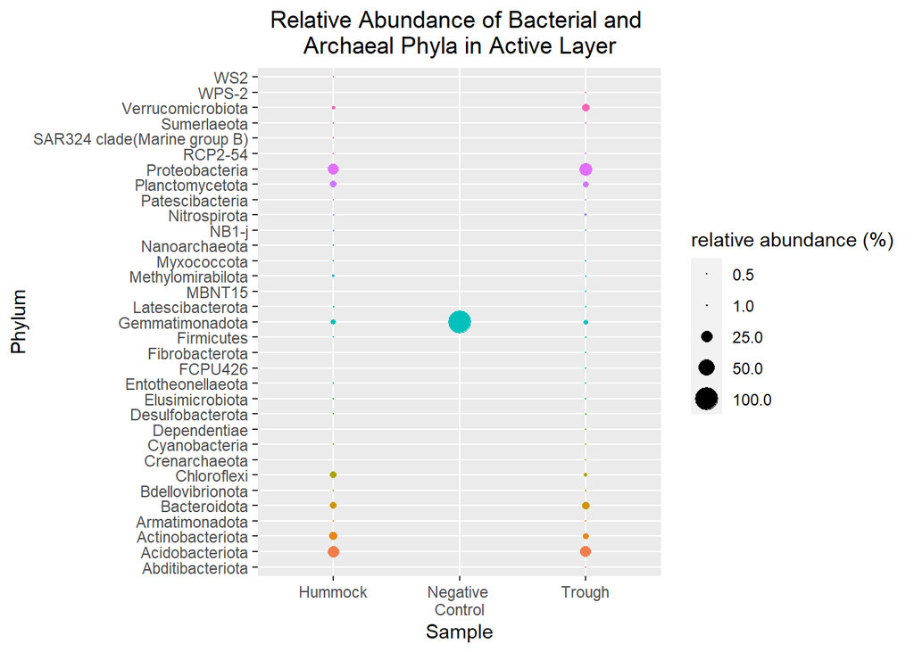

```r
ggplot(data = phy, aes(x=Sample, y=Phylum, size = Abundance, colour=Phylum)) +  geom_point(stroke = 0) +  scale_size_area( breaks = c(0.5, 1, 25, 50, 100),name = "relative abundance (%)") + guides(colour=FALSE) +                 labs(y="Phylum",title="Relative Abundance of Bacterial and \nArchaeal Phyla in Active Layer",x= "Sample")   + scale_x_discrete(labels=c("Hummock","Negative \nControl","Trough")) + theme(plot.title = element_text(hjust = 0.5))
```

Export all graphs to save as images